# Flight Activity

## Preliminary Wrangling

I pulled two months of flight activity data from the [US Bureau of Transportation Statistics](https://www.transtats.bts.gov/DL_SelectFields.asp). The first month is from September 2001 and the second month is from March of 2020. My reason for focusing on these two months is they were both periods of great upheaval in the airline industry, and I was curious about similarities and differences between the two periods. Since there can are large numbers of flights in the US every month, I kept my data selection to just these two months rather than expanding out to other months.

```python
# import all packages and set plots to be embedded inline
import numpy as np
import pandas as pd
import matplotlib.pyplot as plt
import seaborn as sb

%matplotlib inline
```

```python
flights_2001 = pd.read_csv('09_2001_Flight_Activity.csv', encoding='latin-1') #added the latin encoding because of strange characters in the tail number
flights_2020 = pd.read_csv('03_2020_Flight_Activity.csv')
```

```python
flights_2001.head()
```

|  | YEAR | QUARTER | MONTH | DAY_OF_MONTH | DAY_OF_WEEK | FL_DATE | OP_UNIQUE_CARRIER | TAIL_NUM | OP_CARRIER_FL_NUM | ORIGIN | ... | ARR_DEL15 | CANCELLED | CANCELLATION_CODE | DIVERTED | CRS_ELAPSED_TIME | ACTUAL_ELAPSED_TIME | AIR_TIME | DISTANCE | DISTANCE_GROUP | Unnamed: 30 |
| --- | --- | --- | --- | --- | --- | --- | --- | --- | --- | --- | --- | --- | --- | --- | --- | --- | --- | --- | --- | --- | --- |
| 0 | 2001 | 3 | 9 | 16 | 7 | 2001-09-16 | AA | äNKNOæ | 715 | LGA | ... | NaN | 1.0 | NaN | 0.0 | 221.0 | NaN | NaN | 1389.0 | 6 | NaN |
| 1 | 2001 | 3 | 9 | 17 | 1 | 2001-09-17 | AA | N558A1 | 715 | LGA | ... | 0.0 | 0.0 | NaN | 0.0 | 221.0 | 202.0 | 184.0 | 1389.0 | 6 | NaN |
| 2 | 2001 | 3 | 9 | 18 | 2 | 2001-09-18 | AA | N524A1 | 715 | LGA | ... | 0.0 | 0.0 | NaN | 0.0 | 221.0 | 216.0 | 192.0 | 1389.0 | 6 | NaN |
| 3 | 2001 | 3 | 9 | 19 | 3 | 2001-09-19 | AA | N501A1 | 715 | LGA | ... | 0.0 | 0.0 | NaN | 0.0 | 221.0 | 226.0 | 209.0 | 1389.0 | 6 | NaN |
| 4 | 2001 | 3 | 9 | 20 | 4 | 2001-09-20 | AA | N509A1 | 715 | LGA | ... | 0.0 | 0.0 | NaN | 0.0 | 221.0 | 216.0 | 201.0 | 1389.0 | 6 | NaN |

5 rows × 31 columns

```python
flights_2020.head()
```

|  | YEAR | QUARTER | MONTH | DAY_OF_MONTH | DAY_OF_WEEK | FL_DATE | OP_UNIQUE_CARRIER | TAIL_NUM | OP_CARRIER_FL_NUM | ORIGIN | ... | ARR_DEL15 | CANCELLED | CANCELLATION_CODE | DIVERTED | CRS_ELAPSED_TIME | ACTUAL_ELAPSED_TIME | AIR_TIME | DISTANCE | DISTANCE_GROUP | Unnamed: 30 |
| --- | --- | --- | --- | --- | --- | --- | --- | --- | --- | --- | --- | --- | --- | --- | --- | --- | --- | --- | --- | --- | --- |
| 0 | 2020 | 1 | 3 | 12 | 4 | 2020-03-12 | AA | N764US | 1523 | PSP | ... | 1.0 | 0.0 | NaN | 0.0 | 172.0 | 164.0 | 129.0 | 1126.0 | 5 | NaN |
| 1 | 2020 | 1 | 3 | 13 | 5 | 2020-03-13 | AA | N758US | 1523 | PSP | ... | 0.0 | 0.0 | NaN | 0.0 | 172.0 | 164.0 | 141.0 | 1126.0 | 5 | NaN |
| 2 | 2020 | 1 | 3 | 14 | 6 | 2020-03-14 | AA | N314PD | 1523 | PSP | ... | 0.0 | 0.0 | NaN | 0.0 | 172.0 | 162.0 | 137.0 | 1126.0 | 5 | NaN |
| 3 | 2020 | 1 | 3 | 15 | 7 | 2020-03-15 | AA | N177XF | 1523 | PSP | ... | 0.0 | 0.0 | NaN | 0.0 | 172.0 | 161.0 | 138.0 | 1126.0 | 5 | NaN |
| 4 | 2020 | 1 | 3 | 16 | 1 | 2020-03-16 | AA | N831AW | 1523 | PSP | ... | NaN | 1.0 | D | 0.0 | 172.0 | NaN | NaN | 1126.0 | 5 | NaN |

5 rows × 31 columns

```python
#append the March 2020 flights to the September 2001 flights
flights = flights_2001.append(flights_2020)
```

```python
flights.shape
```

```
(1138927, 31)
```

```python
flights.dtypes
```

```
YEAR                     int64
QUARTER                  int64
MONTH                    int64
DAY_OF_MONTH             int64
DAY_OF_WEEK              int64
FL_DATE                 object
OP_UNIQUE_CARRIER       object
TAIL_NUM                object
OP_CARRIER_FL_NUM        int64
ORIGIN                  object
ORIGIN_CITY_NAME        object
ORIGIN_STATE_ABR        object
DEST                    object
DEST_CITY_NAME          object
DEST_STATE_ABR          object
CRS_DEP_TIME             int64
DEP_TIME               float64
DEP_DELAY              float64
CRS_ARR_TIME             int64
ARR_TIME               float64
ARR_DELAY              float64
ARR_DEL15              float64
CANCELLED              float64
CANCELLATION_CODE       object
DIVERTED               float64
CRS_ELAPSED_TIME       float64
ACTUAL_ELAPSED_TIME    float64
AIR_TIME               float64
DISTANCE               float64
DISTANCE_GROUP           int64
Unnamed: 30            float64
dtype: object
```

```python
flights.info()
```

```
<class 'pandas.core.frame.DataFrame'>
Int64Index: 1138927 entries, 0 to 648228
Data columns (total 31 columns):
 #   Column               Non-Null Count    Dtype
---  ------               --------------    -----
 0   YEAR                 1138927 non-null  int64
 1   QUARTER              1138927 non-null  int64
 2   MONTH                1138927 non-null  int64
 3   DAY_OF_MONTH         1138927 non-null  int64
 4   DAY_OF_WEEK          1138927 non-null  int64
 5   FL_DATE              1138927 non-null  object
 6   OP_UNIQUE_CARRIER    1138927 non-null  object
 7   TAIL_NUM             1090606 non-null  object
 8   OP_CARRIER_FL_NUM    1138927 non-null  int64
 9   ORIGIN               1138927 non-null  object
```

[output cut: 23 more lines]

```python
# Don't need either of these columns
flights.drop(['QUARTER', 'Unnamed: 30'], axis=1, inplace=True)
```

```python
flights.info()
```

```
<class 'pandas.core.frame.DataFrame'>
Int64Index: 1138927 entries, 0 to 648228
Data columns (total 29 columns):
 #   Column               Non-Null Count    Dtype
---  ------               --------------    -----
 0   YEAR                 1138927 non-null  int64
 1   MONTH                1138927 non-null  int64
 2   DAY_OF_MONTH         1138927 non-null  int64
 3   DAY_OF_WEEK          1138927 non-null  int64
 4   FL_DATE              1138927 non-null  object
 5   OP_UNIQUE_CARRIER    1138927 non-null  object
 6   TAIL_NUM             1090606 non-null  object
 7   OP_CARRIER_FL_NUM    1138927 non-null  int64
 8   ORIGIN               1138927 non-null  object
 9   ORIGIN_CITY_NAME     1138927 non-null  object
```

[output cut: 21 more lines]

```python
#Convert FL_DATE column to datetime formart
flights['FL_DATE'] = pd.to_datetime(flights['FL_DATE'])
```

```python
#Fill nulls for the ARR_DEL15 column with 0 and then convert it to a boolean
#We are assuming that if a value is null, then it is False. This could create false negatives, which are better than false positives
flights['ARR_DEL15'].fillna(0, inplace=True)
flights['ARR_DEL15'] = flights['ARR_DEL15'].astype('bool')
```

```python
flights['CANCELLED'] = flights['CANCELLED'].astype('bool')
```

```python
flights['DIVERTED'] = flights['DIVERTED'].astype('bool')
```

```python
flights.info()
```

```
<class 'pandas.core.frame.DataFrame'>
Int64Index: 1138927 entries, 0 to 648228
Data columns (total 29 columns):
 #   Column               Non-Null Count    Dtype
---  ------               --------------    -----
 0   YEAR                 1138927 non-null  int64
 1   MONTH                1138927 non-null  int64
 2   DAY_OF_MONTH         1138927 non-null  int64
 3   DAY_OF_WEEK          1138927 non-null  int64
 4   FL_DATE              1138927 non-null  datetime64[ns]
 5   OP_UNIQUE_CARRIER    1138927 non-null  object
 6   TAIL_NUM             1090606 non-null  object
 7   OP_CARRIER_FL_NUM    1138927 non-null  int64
 8   ORIGIN               1138927 non-null  object
 9   ORIGIN_CITY_NAME     1138927 non-null  object
```

[output cut: 21 more lines]

### What is/are the main feature(s) of interest in your dataset?

I'm interested in exploring the number of flights over the course of each month. Additionally, I want to see how cancellations, delays, and diversions were impacted due to the September 11th attacks and the COVID-19 pandemic

### What features in the dataset do you think will help support your investigation into your feature(s) of interest?

To explore these features of interest, I'll take a look at number of flights during each day of the month, I'll explore the delay times as well as the delayed 15 minutes boolean field, and even get into the diverted boolean as well.

## Univariate Exploration

Let's start by looking at the number of flights (number of records) by day of the month. This is going to be a lot of data, so it will be pretty wide.

```python
base_color = sb.color_palette()[0] #Set the base color to use throughout the visualizations
```

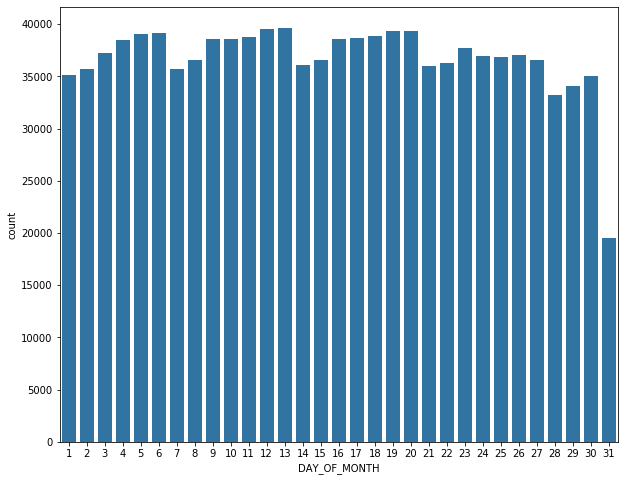

```python
plt.figure(figsize=[10,8]) #Make the figure larger
sb.countplot(data=flights, x='DAY_OF_MONTH', color=base_color)
```

Well that doesn't yield too much interesting data. Notice that the 31st day of the month is significantly shorter than the other bars. That's because we're looking at both March 2020 and September 2001 in the same plot, and September doesn't have any data. Let's look at the same plot again, but split out the chart so that we only plot one month at a time.

```python
flights_01 = flights.query('YEAR == 2001') #Flights in September 2001
flights_20 = flights.query('YEAR == 2020') #Flights in March 2020
```

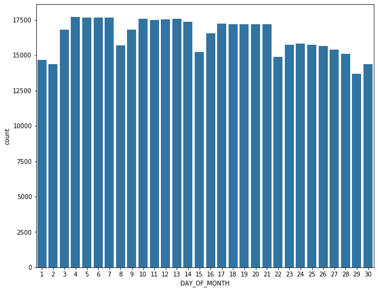

```python
plt.figure(figsize=[10,8]) #Make the figure larger
sb.countplot(data=flights_01, x='DAY_OF_MONTH', color=base_color);
```

Interesting! I would have expected a dip in the number of flights on September 12th. What about March 2020?

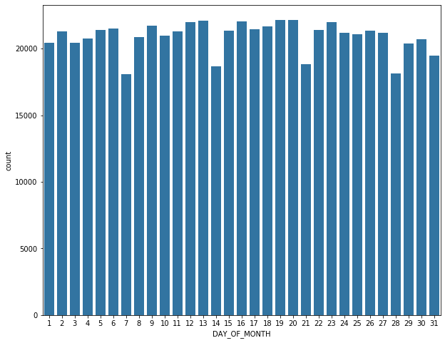

```python
plt.figure(figsize=[10,8]) #Make the figure larger
sb.countplot(data=flights_20, x='DAY_OF_MONTH', color=base_color);
```

Interesting. I would have expected a bigger dip in the number of flights around March 13-17th. Let's take a look at the number of cancellations. Remember, we're sticking with univariate explorations of data at the moment. So we won't look at number of cancellations over time right now; we'll save that for later.

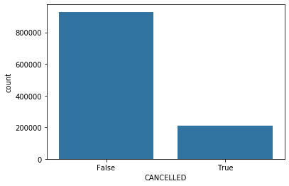

```python
sb.countplot(data=flights, x='CANCELLED', color=base_color);
```

Naturally, most flights were not cancelled. What about delays? Let's start by looking at the boolean of whether an arrival was delayed by more than 15 minutes.

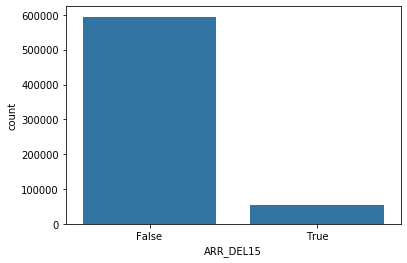

```python
sb.countplot(data=flights_20, x='ARR_DEL15', color=base_color);
```

Even fewer flights were delayed by 15 minutes or more than were cancelled. Let's look at the distribution of departure delays.

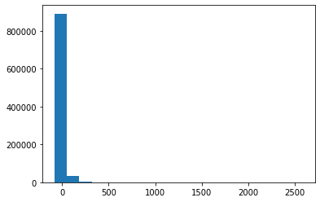

```python
plt.hist(data=flights, x='DEP_DELAY', bins=20);
```

It looks like there are some HUGE delays! Could you imagine being delayed by 2500 minutes? That's nearly 42 hours! It'll be interesting later on to see if we can find when those delays occurred (and I have a guess). In the meantime, let's try this histogram again, focusing in on where most of the data resides. Let's use .describe() to find the min, max, and IQR for departure delays.

```python
flights.DEP_DELAY.describe()
```

```
count    929647.00000
mean          3.76578
std          32.87731
min         -80.00000
25%          -6.00000
50%          -3.00000
75%           0.00000
max        2579.00000
Name: DEP_DELAY, dtype: float64
```

75% of flights have a departure delay of 0 or less. Now, a negative delay means that the flight left early. Let's limit the x-axis of the histogram to between -100 and 100.

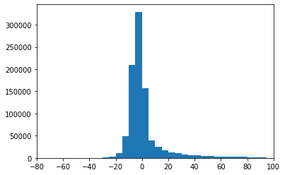

```python
bin_edges = np.arange(flights.DEP_DELAY.min(), 100, 5)
plt.xlim(-80, 100)
plt.hist(data=flights, x='DEP_DELAY', bins=bin_edges);
```

This is a unimodal distribution, with the majority of flights having no departure delay. There is a strong right-skew to the data. Let's take a look at arrival delays now.

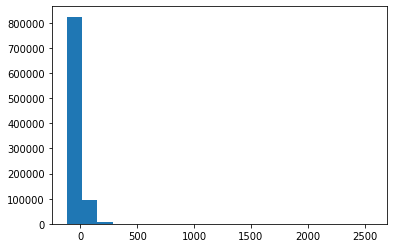

```python
plt.hist(data=flights, x='ARR_DELAY', bins=20);
```

Once again, we have strong right skew. Let's do what we did for departure delays, focusing on the most common arrival delay times.

```python
flights.ARR_DELAY.describe()
```

```
count    927232.000000
mean         -2.718911
std          35.484587
min        -117.000000
25%         -17.000000
50%          -9.000000
75%           1.000000
max        2560.000000
Name: ARR_DELAY, dtype: float64
```

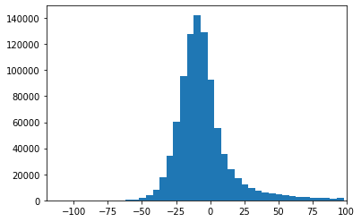

```python
bin_edges = np.arange(flights.ARR_DELAY.min(), 100, 5)
plt.xlim(-120, 100)
plt.hist(data=flights, x='ARR_DELAY', bins=bin_edges);
```

Once again, the data is skewed to the right. The peak for arrival delays is not as tall, and it's actually less than 0. Let's now plot the distribution of actual time (time between departure and arrival).

```python
flights.ACTUAL_ELAPSED_TIME.describe()
```

```
count    927232.000000
mean        130.126474
std          71.537523
min          15.000000
25%          77.000000
50%         112.000000
75%         162.000000
max         763.000000
Name: ACTUAL_ELAPSED_TIME, dtype: float64
```

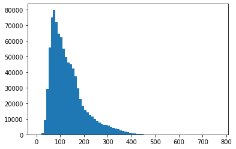

```python
bin_edges = np.arange(0, flights.ACTUAL_ELAPSED_TIME.max()+10, 10)
plt.hist(data=flights, x='ACTUAL_ELAPSED_TIME', bins=bin_edges);
```

We've got another right-skewed unimodal distribution for actual elapsed time. The average is 130 minutes. Let's now look at air time, which should be fairly similar to actual elapsed time but just slightly shorter.

```python
flights.AIR_TIME.describe()
```

```
count    927232.000000
mean        108.231959
std          69.355949
min           5.000000
25%          57.000000
50%          90.000000
75%         139.000000
max         694.000000
Name: AIR_TIME, dtype: float64
```

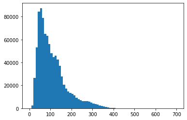

```python
bin_edges = np.arange(0, flights.AIR_TIME.max()+10, 10)
plt.hist(data=flights, x='AIR_TIME', bins=bin_edges);
```

Once again, air time is a right-skewed unimodal distribution. The mean is 108. Let's take a look at distance now.

```python
flights.DISTANCE.describe()
```

```
count    1.138927e+06
mean     7.725789e+02
std      5.803826e+02
min      3.100000e+01
25%      3.370000e+02
50%      6.120000e+02
75%      1.014000e+03
max      5.095000e+03
Name: DISTANCE, dtype: float64
```

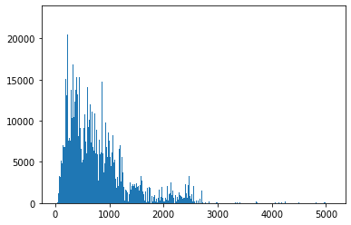

```python
bin_edges = np.arange(0, flights.DISTANCE.max()+10, 10)
plt.hist(data=flights, x='DISTANCE', bins=bin_edges);
```

Once again, we have a right-skewed unimodal distribution. I could have smoothed out the histogram by making the bins larger (100 miles for instance), but I thought that this was more interesting.

Let's now take a look at number of flights by carrier.

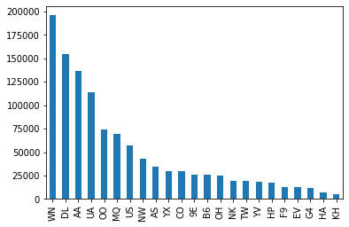

```python
flights['OP_UNIQUE_CARRIER'].value_counts().plot(kind='bar')
```

The top five airlines in these two months by number of flights are Southwest Airlines (WN), Delta Airlines, American Airlines, United Airlines, and SkyWest Airlines. Let's now take a look at the top 10 destinations. It wouldn't be productive to look at much more than the top 10 airports because we'd likely get lost in the sheer number of locations.

```python
flights.DEST.value_counts().head(10)
```

```
ORD    56111
ATL    54571
DFW    50916
LAX    37150
DEN    33197
PHX    32147
CLT    31408
DTW    26878
LAS    26293
IAH    26258
Name: DEST, dtype: int64
```

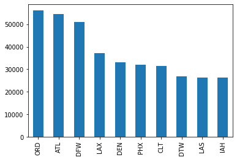

```python
flights.DEST.value_counts().nlargest(10).plot(kind='bar')
```

Very interesting! If we wanted to see which cities have the most flights, we can use the DEST_CITY_NAME column:

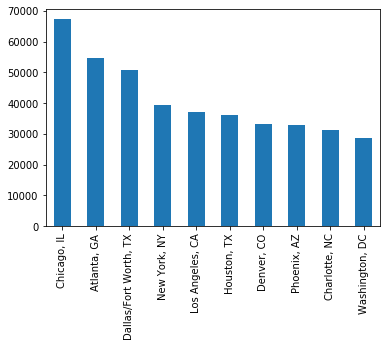

```python
flights.DEST_CITY_NAME.value_counts().nlargest(10).plot(kind='bar')
```

Something that I didn't expect here was to see major difference between the top 10 airports and the top 10 cities. I forget that many cities (like Chicago) have multiple airports.

### Discuss the distribution(s) of your variable(s) of interest. Were there any unusual points? Did you need to perform any transformations? Of the features you investigated, were there any unusual distributions? Did you perform any operations on the data to tidy, adjust, or change the form of the data? If so, why did you do this?

To recap what we just did: we cleaned the data by changing several data types (arrived by 15 minutes late, cancelled, and diverted) and filling in null values for the arrived by 15 minutes late boolean column. Several interesting points to note:

- We explored the data by day of the month, and even split this into two separate plots: one for September 2001 and one for March 2020.
- Most flights were not cancelled, and most did not arrive later than 15 minutes.
- We explored the distribution of several of our numeric variables using histograms. Departure delay, arrival delay, actual elapsed time, air time, and distance were all right-skewed, unimodal distributions.
- We looked at the number of flights per carrier and found the top carriers by number of flights.
- We looked at the top destination airports and top destination cities. These were not the same because a city could have multiple airports.

## Bivariate Exploration

Let's start by looking at flight cancellations by day of the month in September 2001.

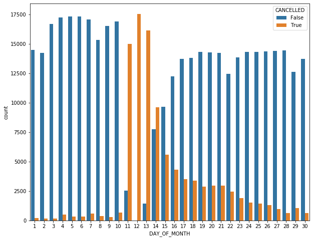

```python
plt.figure(figsize=[10,8]) #Make the figure larger
sb.countplot(data=flights_01, x='DAY_OF_MONTH', hue='CANCELLED');
```

Oh! So while the number of flights that were scheduled were relatively unchanged throughout the course of the month, there was a huge spike in the number of cancelled flights on and after September 11th. This is more in line with what I would have expected to see. What about March 2020? Did we see a similar spike in cancellations?

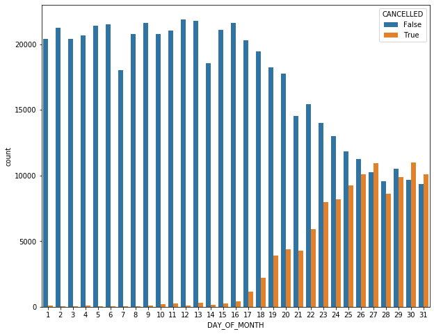

```python
plt.figure(figsize=[10,8]) #Make the figure larger
sb.countplot(data=flights_20, x='DAY_OF_MONTH', hue='CANCELLED');
```

Interesting. So this is quite a bit different than the impact that September 11th had on the airline industry. 9/11 caused a huge spike in cancellations. COVID-19, however, gradually caused more and more flights to be cancelled, starting March 17th and then growing through the end of the month. What about the arrival delayed by more than 15 minutes flag? What does that look like over the course of the month of September 2001?

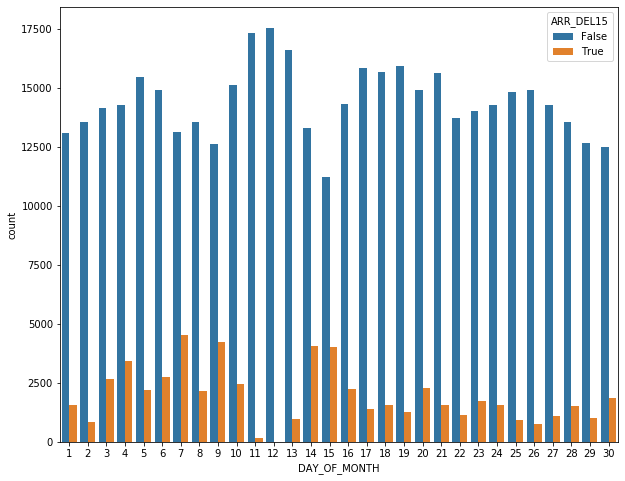

```python
plt.figure(figsize=[10,8]) #Make the figure larger
sb.countplot(data=flights_01, x='DAY_OF_MONTH', hue='ARR_DEL15');
```

The only interesting data points here would be September 11th and September 12th. With very few flights occurring on those days, many flights were cancelled and very few had arrival delays greater than 15 minutes. What about March 2020?

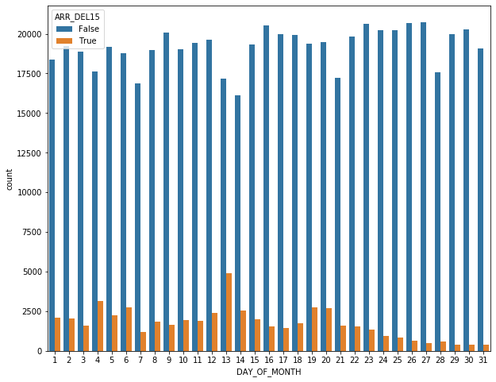

```python
plt.figure(figsize=[10,8]) #Make the figure larger
sb.countplot(data=flights_20, x='DAY_OF_MONTH', hue='ARR_DEL15');
```

There's a small downward trend from March 20th to the end of the month in the number of flights with arrival delays of greater than 15 minutes.

Let's now turn to look at the distributions of our numeric variables of interest. Let's start by plotting a Pair Grid.

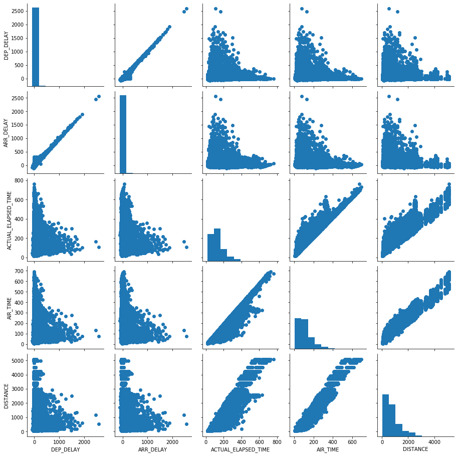

```python
g = sb.PairGrid(data=flights, vars=['DEP_DELAY', 'ARR_DELAY', 'ACTUAL_ELAPSED_TIME', 'AIR_TIME', 'DISTANCE'])
g.map_diag(plt.hist)
g.map_offdiag(plt.scatter)
```

This wasn't as interesting as I thought it might be. Obviously there's a linear relationship between departure delays and arrival delays. There's also correlation between actual elapsed time and air time, and each of these and distance.

Let's take a look at departure delays by origin airport, but let's just look at flights in the top three airports; ORD (Chicago O'Hare), ATL (Atlanta), DFW (Dallas - Fort Worth).

```python
flights_origin = flights.query('ORIGIN == "ORD" | ORIGIN == "ATL" | ORIGIN == "DFW"')
```

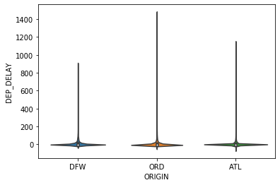

```python
sb.violinplot(data=flights_origin, x='ORIGIN', y='DEP_DELAY')
```

That's not very informative. Let's try a boxplot.

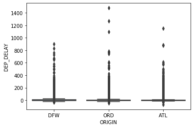

```python
sb.boxplot(data=flights_origin, x='ORIGIN', y='DEP_DELAY')
```

Once again, there's just a lot of outliers, obscuring the true nature of the boxes. Let's try looking at the data with a violin plot again, but let's limit the y-axis to less that 100.

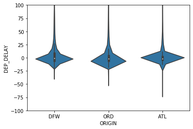

```python
plt.ylim(-100, 100)
sb.violinplot(data=flights_origin, x='ORIGIN', y='DEP_DELAY', color=base_color)
```

The "violins" look more like diamonds. What about a box plot? Right now, I'm just testing different things out to see what works best.

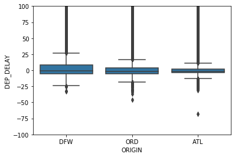

```python
plt.ylim(-100, 100)
sb.boxplot(data=flights_origin, x='ORIGIN', y='DEP_DELAY', color=base_color)
```

DFW has the widest IQR, followed by ORD and then ATL. Let's do something similar with destination airports and arrival delays.

```python
#Filter down to just ORD, ATL, and DFW
flights_destination = flights.query('DEST == "ORD" | DEST == "ATL" | DEST == "DFW"')
```

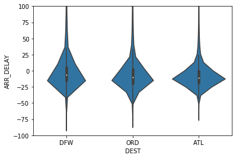

```python
plt.ylim(-100, 100)
sb.violinplot(data=flights_destination, x='DEST', y='ARR_DELAY', color=base_color)
```

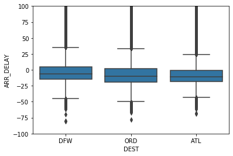

```python
plt.ylim(-100, 100)
sb.boxplot(data=flights_destination, x='DEST', y='ARR_DELAY', color=base_color)
```

Nothing too interesting here. The airports have a similar spread of delays when they are the destination airport. What is the distribution of actual elapsed time when they are the origin?

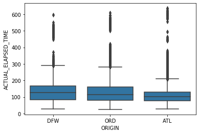

```python
sb.boxplot(data=flights_origin, x='ORIGIN', y='ACTUAL_ELAPSED_TIME', color=base_color)
```

ATL has the most skew of the three. What about distance?

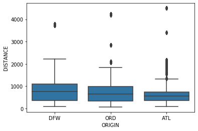

```python
sb.boxplot(data=flights_origin, x='ORIGIN', y='DISTANCE', color=base_color)
```

DFW has the widest IQR, followed by ORD, and then ATL. Could this be because DFW and ORD are in the middle of the country? I don't think this is a question that could be answered by this dataset.

What's the relationship between carrier and arrival delays? Is one carrier better than the others in these two months?

```python
top_carriers = flights.query('OP_UNIQUE_CARRIER == "WN" | OP_UNIQUE_CARRIER == "DL" | OP_UNIQUE_CARRIER == "AA" | OP_UNIQUE_CARRIER == "UA"')
```

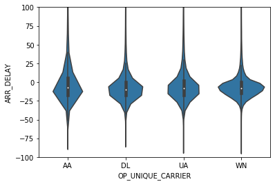

```python
plt.ylim(-100, 100)
sb.violinplot(data=top_carriers, x='OP_UNIQUE_CARRIER', y='ARR_DELAY', color=base_color)
```

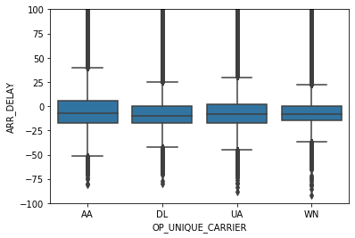

```python
plt.ylim(-100, 100)
sb.boxplot(data=top_carriers, x='OP_UNIQUE_CARRIER', y='ARR_DELAY', color=base_color)
```

Southwest Airlines (WN) has the smallest IQR, while American Airlines (AA) has the widest. All four carriers have a lot of skew to the right.

Let's now take a look at the distribution of departure delays during the week of the September 11th attacks.

```python
#Filter down to the flights between September 9-15, 2001
flights_sep_week = flights.query('MONTH == 9 & DAY_OF_MONTH >=9 & DAY_OF_MONTH <=15')
```

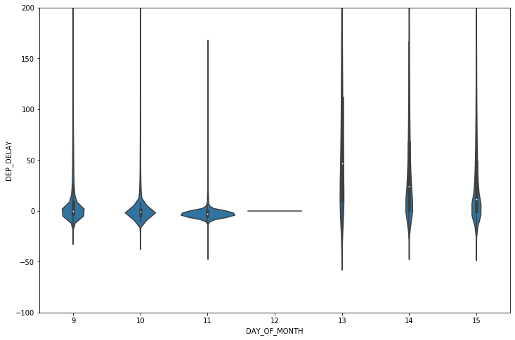

```python
plt.figure(figsize=[12,8])
plt.ylim(-100,200)
sb.violinplot(data=flights_sep_week, x='DAY_OF_MONTH', y='DEP_DELAY', color=base_color)
```

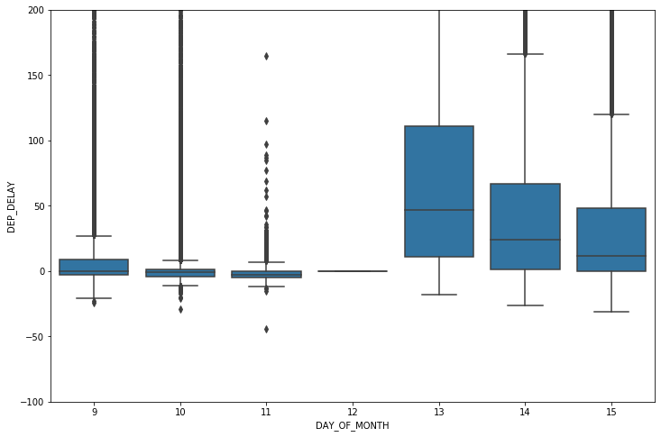

```python
plt.figure(figsize=[12,8])
plt.ylim(-100,200)
sb.boxplot(data=flights_sep_week, x='DAY_OF_MONTH', y='DEP_DELAY', color=base_color)
```

Look at how thin the violin plots are on September 13th, 14th, and 15th! That's crazy. Another way to visualize it is to look at the box plot as well. Notice how the IQR is much larger and is also above 0 during the last three days of the week. Notice that there were virtually no flights on September 12th. Imagine the chaos at the airports during that turbulent week.

What about actual time elapsed during the week? Was it impacted at all?

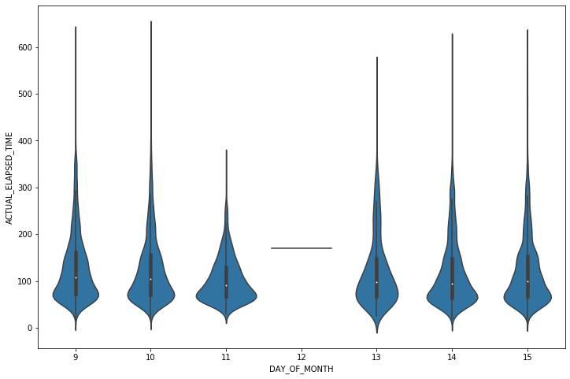

```python
plt.figure(figsize=[12,8])
sb.violinplot(data=flights_sep_week, x='DAY_OF_MONTH', y='ACTUAL_ELAPSED_TIME', color=base_color)
```

Let's move on to the last 7 days of March: March 25-31, 2020 and see what the impact to delays was.

```python
#Filter down to the flights between March 25-31, 2020
flights_march_week = flights.query('MONTH == 3 & DAY_OF_MONTH >=25 & DAY_OF_MONTH <=31')
```

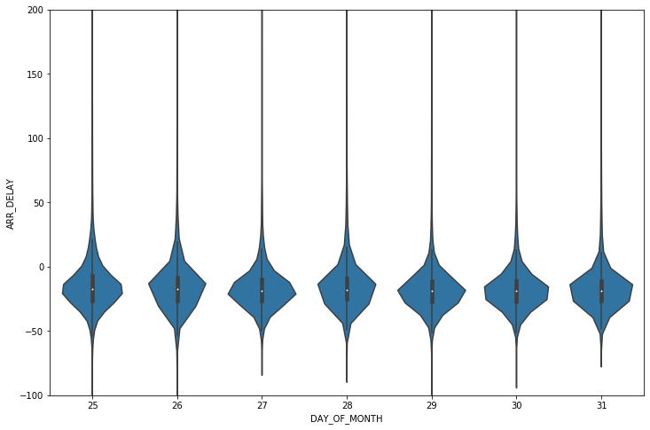

```python
plt.figure(figsize=[12,8])
plt.ylim(-100,200)
sb.violinplot(data=flights_march_week, x='DAY_OF_MONTH', y='ARR_DELAY', color=base_color)
```

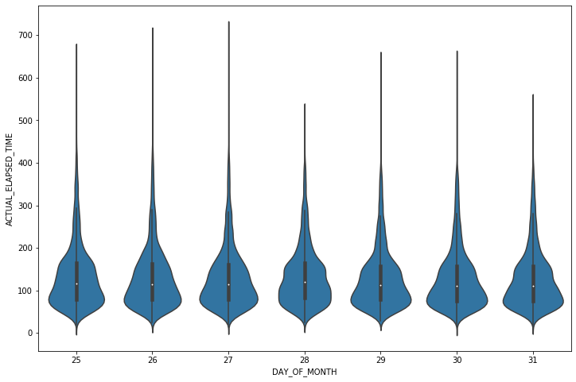

```python
plt.figure(figsize=[12,8])
sb.violinplot(data=flights_march_week, x='DAY_OF_MONTH', y='ACTUAL_ELAPSED_TIME', color=base_color)
```

Neither the arrival delays nor the actual elapsed time seem to be all that strikingly different over the course of the last week of the month. What about if we plotted the whole month and summed the actual elapsed time? Would it decrease towards the end of the month?

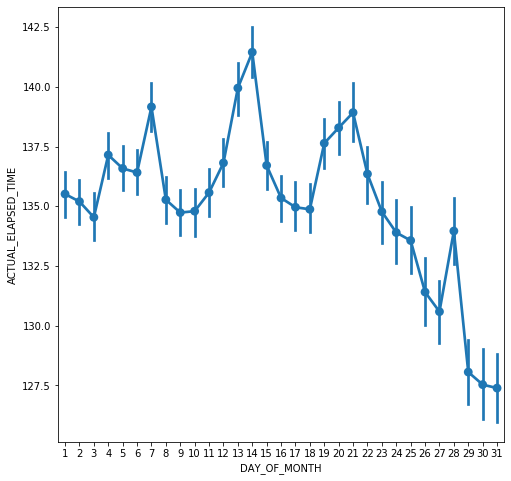

```python
plt.figure(figsize=[8,8])
sb.pointplot(data=flights_20, x='DAY_OF_MONTH', y='ACTUAL_ELAPSED_TIME', color=base_color);
```

We can see that there is a decrease in the average flight time during the second half of the month. Be careful with this visualization, though, because the y-axis doesn't start at 0. Let's set the y-axis to start at 0. We don't want to overstate the decrease in the average flight time.

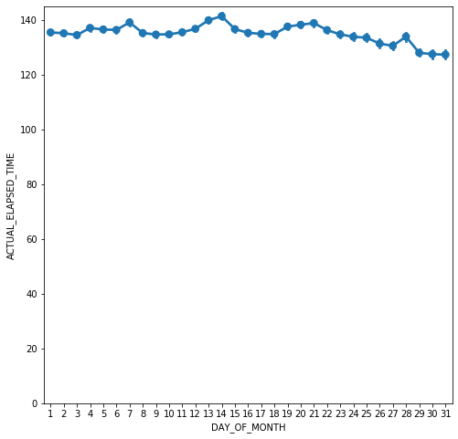

```python
plt.figure(figsize=[8,8])
plt.ylim(0,145)
sb.pointplot(data=flights_20, x='DAY_OF_MONTH', y='ACTUAL_ELAPSED_TIME', color=base_color);
```

We can still see a decrease, but its not as pronounced.

### Talk about some of the relationships you observed in this part of the investigation. How did the feature(s) of interest vary with other features in the dataset?

In this section, we saw how 9/11 had a strong impact on the number of cancellations on September 11-13, 2001. COVID-19 impacted the number of cancelled flights more gradually, with cancellations exceeding the number of flights by the end of March. There wasn't much interesting information in the relationships between depature delay, arrival delay, actual elapsed time, air time, or distance.

### Did you observe any interesting relationships between the other features (not the main feature(s) of interest)?

When we plotted the distribution of departure delays, arrival delays, actual elapsed time, and distance against the three top airports (ORD, ATL, and DFW), we noticed once again that the data was quite skewed to the right. The same was true when plotting arrival delays for the four major carriers (Southwest, Delta, American, and United).

## Multivariate Exploration

Now we get to the good part. How did the major events in September 2001 and March 2020 impact our three major airports and four major carriers? Let's explore, starting with the week of the 9/11 attacks.

```python
#Query the dataframe that is just the one week of September for the top three origin airports
origins_sep_week = flights_sep_week.query('ORIGIN == "ORD" | ORIGIN == "ATL" | ORIGIN == "DFW"')
```

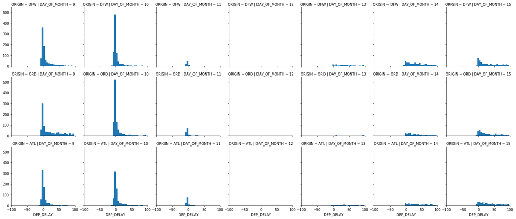

```python
bin_edges = np.arange(flights_sep_week.DEP_DELAY.min(), 100, 5)
g = sb.FacetGrid(data=origins_sep_week, col='DAY_OF_MONTH', row='ORIGIN')
g.map(plt.hist, 'DEP_DELAY', bins=bin_edges)
g.set(xlim=(-100,100))
```

So things seemed to be running pretty normally at each of these airports on September 9th and 10th. Then there were very few flights on the 11th, no flights on the 12th, and then the delays were much more skewed during the last three days of the week. All three of the airports were affected. What about the four major carriers? Were they impacted?

```python
#Query the dataframe that is just the one week of September for the top four carriers
carriers_sep_week = flights_sep_week.query('OP_UNIQUE_CARRIER == "WN" | OP_UNIQUE_CARRIER == "DL" | OP_UNIQUE_CARRIER == "AA" | OP_UNIQUE_CARRIER == "UA"')
```

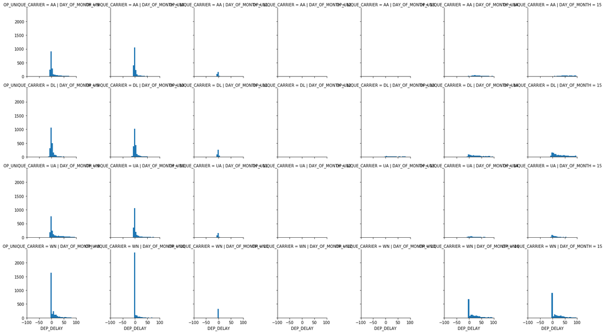

```python
bin_edges = np.arange(flights_sep_week.DEP_DELAY.min(), 100, 5)
g = sb.FacetGrid(data=carriers_sep_week, col='DAY_OF_MONTH', row='OP_UNIQUE_CARRIER')
g.map(plt.hist, 'DEP_DELAY', bins=bin_edges)
g.set(xlim=(-100,100))
```

It looks like all of the carriers were impacted by 9/11, but this seems hard to read. Can we visualize this a different way? Maybe with a bar chart?

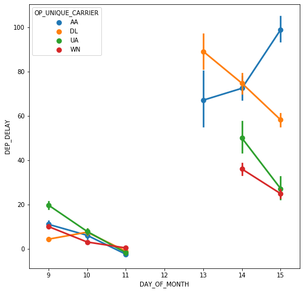

```python
plt.figure(figsize=[8,8])
sb.pointplot(data=carriers_sep_week, x='DAY_OF_MONTH', y='DEP_DELAY', hue='OP_UNIQUE_CARRIER');
```

That tells a more interesting story. The average departure delay was about the same during the beginning of the week. There were no flights on September 12th. Following the shutdown, all four carriers had greater departure delays, but Southwest and United were able to keep there delays lower on average than American and Delta. Let's try something similar with airports.

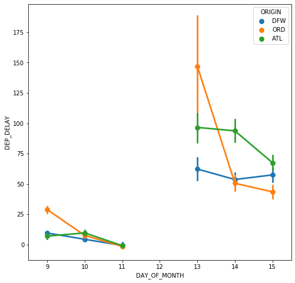

```python
plt.figure(figsize=[8,8])
sb.pointplot(data=origins_sep_week, x='DAY_OF_MONTH', y='DEP_DELAY', hue='ORIGIN');
```

Once again, this tells a better story than the Facet Grid did. You can easily see how the departure delays were fairly similar at the end of the week. Chicago O'Hare had a much higher rate of departure delays than the other two airports on the 13th, but it was able to bring those delays down to below that of the other two on the 14th and 15th.

Let's look at the impacts of COVID-19 on carriers.

```python
#Query the dataframe that is just the month of March for the top four carriers
carriers_march = flights_20.query('OP_UNIQUE_CARRIER == "WN" | OP_UNIQUE_CARRIER == "DL" | OP_UNIQUE_CARRIER == "AA" | OP_UNIQUE_CARRIER == "UA"')
```

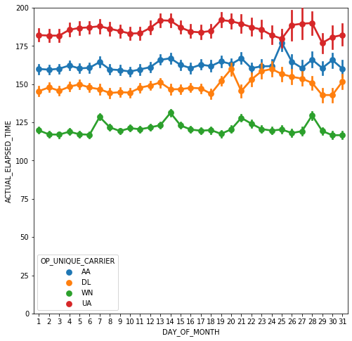

```python
plt.figure(figsize=[8,8])
plt.ylim(0,200)
sb.pointplot(data=carriers_march, x='DAY_OF_MONTH', y='ACTUAL_ELAPSED_TIME', hue='OP_UNIQUE_CARRIER');
```

It's harder to see the decline during the second half of March, but it does appear to be there. Was there an impact on flight times out of our three main airports during that month?

```python
#Query the dataframe that is just the month of March for the top four carriers
origins_march = flights_20.query('ORIGIN == "ORD" | ORIGIN == "ATL" | ORIGIN == "DFW"')
```

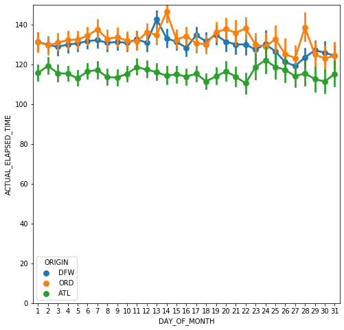

```python
plt.figure(figsize=[8,8])
plt.ylim(0,150)
sb.pointplot(data=origins_march, x='DAY_OF_MONTH', y='ACTUAL_ELAPSED_TIME', hue='ORIGIN');
```

Here, the decline seems more pronounced for DFW and ORD than for ATL. ATL actually has an uptick in average elapsed time during the last week of the month, which is very interesting.

### Talk about some of the relationships you observed in this part of the investigation. Were there features that strengthened each other in terms of looking at your feature(s) of interest?

For the week of September 11th, there were significant disruptions to the carriers' and airports' operations. Departure delays increased significantly for both carriers and for the top three airports. For the month of March 2020, the decrease in flight times was much more subtle when I split out by the top four carriers.

### Were there any interesting or surprising interactions between features?

I was surprised by how much of an impact there was on average departure delays during the week of September 11th. You can see just how flat the distribution is when split out by origin airport. I was also surprised that ATL had an increase in average flight times during the later part of the month of March.